# Meta-Analytic Pooling of Intraclass Correlation Coefficient Estimates

Bethany Hamilton Bhat

Department of Psychiatry and Neuropsychology, Faculty of Health, Medicine and Life Sciences, Maastricht University

15 April 2026

## Meta-Analytic Pooling of Intraclass Correlation Coefficient Estimates

Bhat, B. H., & Beretvas, S. N. (2026). Meta-analytic pooling of intraclass correlation coefficient estimates. Research Synthesis Methods, 1–34. doi:10.1017/rsm.2026.10077

[figure not shown]

## Overview

- Motivation
- Review of Concepts
- Research Questions
- Study Design
- Results
- Conclusions

## Background

- ICCs required for secondary analyses:
  - Prospective power analyses for clustered designs
  - Correcting effect sizes in meta-analysis for clustering (Hedges and Hedberg 2007) or psychometric artifacts (Wiernik and Dahlke 2020)
- ICCs have been used as an outcome in meta-analysis to summarize reliability or clustering effects across studies

## ICC estimate

One-way random effects model:

$$\begin{split}
Level \ 1: Y_{ij} = \beta_{0j} + e_{ij} \\
Level \ 2: \beta_{0j} = \gamma_{00} + u_{0j}
\end{split}$$
where $e_{ij} \sim N(0, \sigma_e^2)$ and $u_{0j} \sim N(0, \sigma^2_u)$

ICC (McGraw and Wong 1996; Fisher 1925):

$$\rho=\frac{\sigma^2_u}{\sigma^2_u+\sigma^2_e}$$

## Sensitivity of Power Analysis to ICC Choice

Example: $\hat{\rho} \in \{0.05, 0.12, 0.18, 0.25\}$

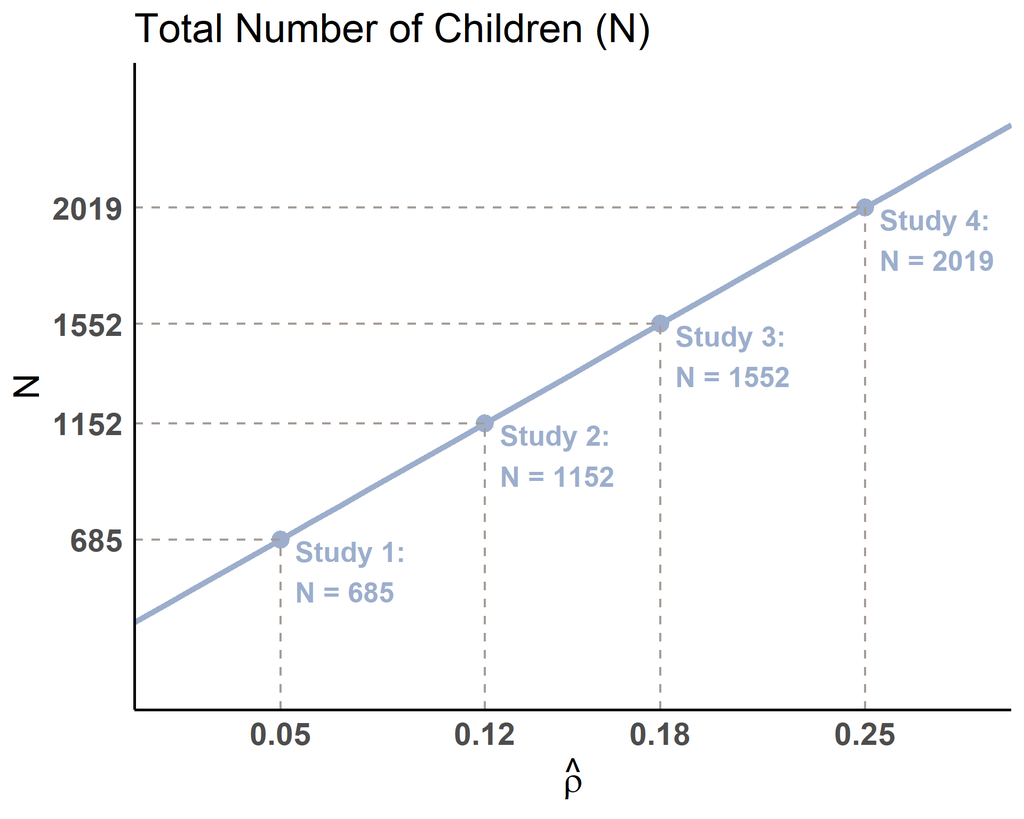

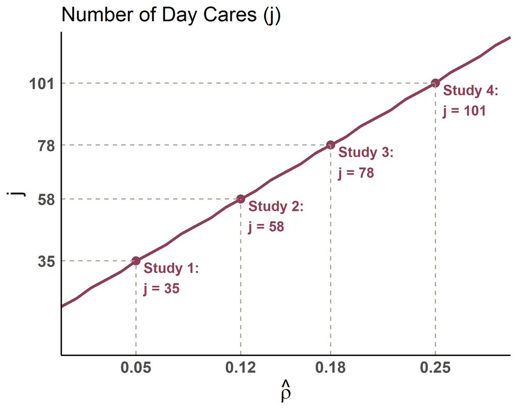

*Note.* Assumptions: $n = 20$; $1 - \beta = 0.80$; $\alpha = 0.05$; $d = 0.3$; power calculation based on design effect approximation (i.e., DEFF=$1 +(n-1) \times \rho$, where $n$ is the average cluster size)

## Why Meta-Analysis?

Meta-analysis:

- Combines ICC estimates using weighted pooling
- Gives more weight to more precise studies

Random-Effects Pooling:

$$\hat{\mu} = \frac{\sum_{i=1}^k w_i T_i}{\sum_{i=1}^k w_i},$$
where $k$ denotes the number of studies, $w_i = \frac{1}{\hat{v}_i+\hat{\tau}^2}$, $T_i$ is the study-specific effect size estimate.

*Note.* Corresponds to random-effects meta-analytic model with variability from: between-study heterogeneity and within-study sampling error

## Sampling Variances of ICC Estimates

Sampling Variance Formulas

| Formula | Equation | Notes |
| --- | --- | --- |
| Fisher (1925) | $v_{\hat{\rho}}=\frac{2(1-\rho)^2[1+(n-1)\rho]^2}{n(n-1)(j-1)}$ | Requires average cluster size and number of clusters |
| Swiger et al. (1964) | $v_{\hat{\rho}}=\frac{2(N-1)(1-\rho^2)[1+(n_0-1)\rho]^2}{n_0^2(N-j)(j-1)}$ | Scaled by total $N$ |
| Hedges et al. (2012) | $v_{\hat{\rho}}=\frac{(1-\rho)^2v_2}{(\sigma_e^2+\sigma^2_u)^2}$ | Requires reported variance components and the variance of the level-2 variance |
| Donner and Koval (1980) | $v_{\hat{\rho}}=\frac{2N(1-\rho)^2}{N\sum_{i=1}^{j}n_i(n_i-1)\hat{V_i}\hat{W_i}^{-2}-\rho^2\Big[\sum_{i=1}^{j}n_i(n_i-1)\hat{W_i}^{-1}\Big]^2}$ | Requires how many level-1 units there are in each cluster, but reduces to Fisher when balanced |
| Smith (1957) | $v_{\hat{\rho}}=\frac{2(1-\rho)^2}{n_0^2}\Big(\frac{[1+\rho(n_0-1)]^2}{N-j}+\frac{(j-1)(1-\rho)[1+\rho(2n_0-1)]+\rho^2[\sum n_i^2-2N^{-1}\sum n_i^3+N^{-2}(\sum n_i^2)^2]}{(j-1)^2}\Big)$ | Requires how many level-1 units there are in each cluster |
| Fisher TF | $v_{\hat{\rho}}=0.5\{(j-1)^{-1}+(N-j)^{-1}\}$ | Normalizing transformation; fewest inputs |

## Meta-Analytic Estimation Methods

Assuming a random effects working model with independent ICC estimates, we evaluated:

- **Robust Variance Estimation (RVE)** (Hedges et al. 2010) *(Sandwich / Huber–White-type estimator)*
  - Uses a method-of-moments estimate for $\tau^2$
  - Robust to weight specification
  - Agnostic to distributional assumptions
- **Restricted Maximum Likelihood (REML)** (Viechtbauer et al. 2015)
  - Standard likelihood-based $\tau^2$ estimator
  - Widely used in meta-analysis

*Note.* Differences are expected primarily in estimated standard error, not in the pooled ICC.

## Research Question

How well does pooling of ICC estimates recover the population ICC value:

1. under a random-effects meta-analytic model,
2. using RVE versus REML, and
3. across different sampling variance estimators in the inverse variance weights?

## Study Design

Primary study data were generated and an ICC was estimated for each study ($k$); meta-analytic datasets contained $k = 20, 50,$ or $100$ studies.

Primary study data generation and ICC estimation

| Component | Values |
| --- | --- |
| Number of clusters ($j$) | $\mathcal{U}$[30, 50], $\mathcal{U}$[50, 100] |
| Average units per cluster ($\overline{n}_j$) | $\mathcal{U}$[10, 30], $\mathcal{U}$[30, 50] |
| Degree of imbalance in cluster sizes ($\zeta$) | 0.1, 0.5 *Note.* $n_j \sim \mathcal{U}[\bar{n}_j(1-\zeta),\, \bar{n}_j(1+\zeta)]$ |
| True ICC ($\rho$) | 0.05; 0.10; 0.15; 0.25; 0.50; 0.90 |
| Between-study heterogeneity ($\tau_{\rho}$) | 0.01, 0.02 *Note.* $\tilde{\rho} = \rho + \mathcal{U}(-2\tau_\rho, 2\tau_\rho)$ |
| ICC estimation at primary study level | Unconditional two-level model with REML |

- Bias (PB, RPB)
- RMSE
- SE bias (RSEB)

## Results - PB for pooled ICC

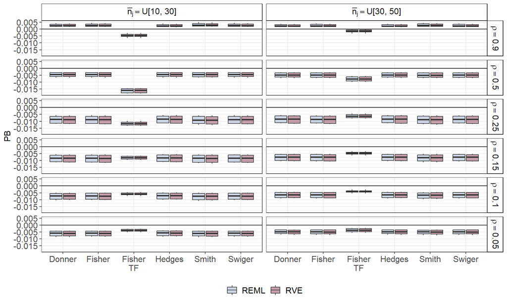

## Results - RPB for Pooled ICC

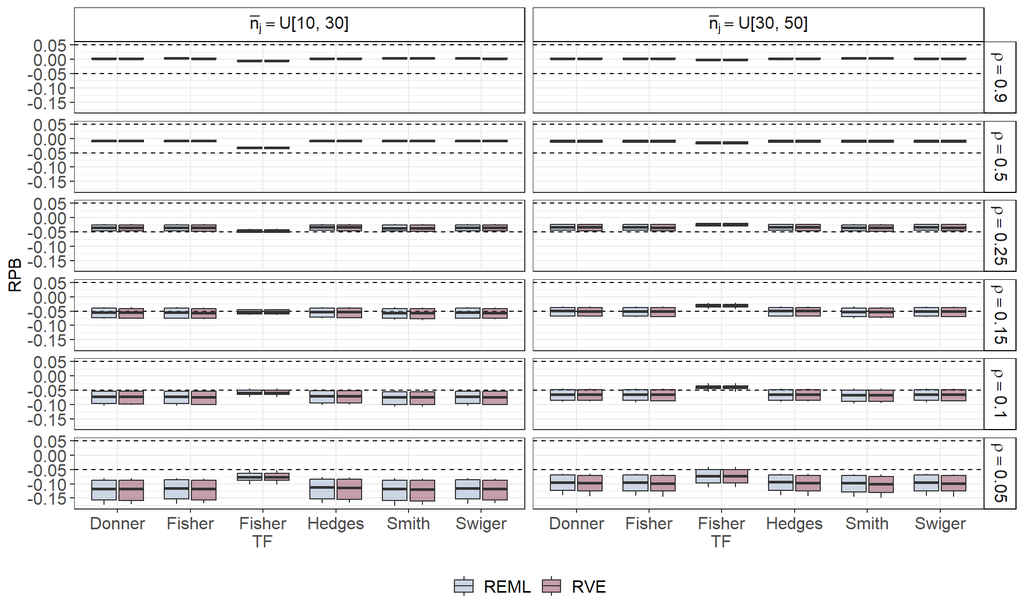

## Results - Relative standard error bias ($\tau_{\rho}$)

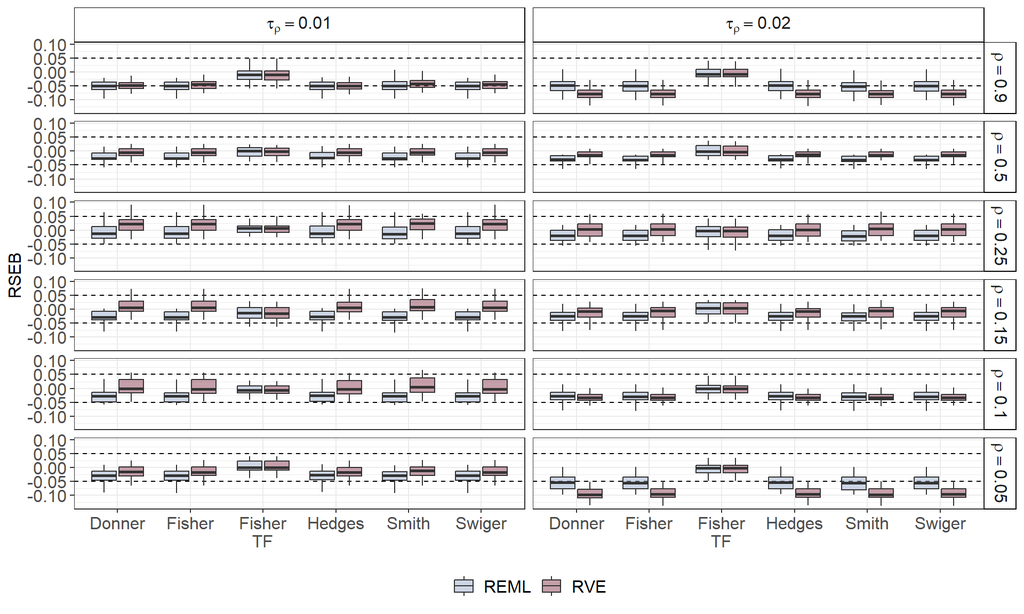

## Conclusions

**Meta-analysis provides a reliable way to obtain a single representative ICC estimate.**

## Future Directions

- Extend to non-normal outcomes (binary, count data)
- Evaluate reliability ICCs with fewer level-1 units
- Extend to three-level and more complex hierarchical structures
- Consider settings with multiple dependent ICCs per study

## Thank you! Questions?

## References

Donner, Allan, and John J. Koval. 1980. “The Estimation of Intraclass Correlation in the Analysis of Family Data.” *Biometrics. Journal of the International Biometric Society* 36 (1): 19–25. https://doi.org/10.2307/2530491.

Fisher, R. A. 1925. “Theory of Statistical Estimation.” *Mathematical Proceedings of the Cambridge Philosophical Society* 22 (5): 700–725. https://doi.org/10.1017/S0305004100009580.

Hedges, Larry V., and E. C. Hedberg. 2007. “Intraclass Correlation Values for Planning Group-Randomized Trials in Education.” *Educational Evaluation and Policy Analysis* 29 (1): 60–87. https://doi.org/10.3102/0162373707299706.

Hedges, Larry V., E. C. Hedberg, and Arend M. Kuyper. 2012. “The Variance of Intraclass Correlations in Three- and Four-Level Models.” *Educational and Psychological Measurement* 72 (6): 893–909. https://doi.org/10.1177/0013164412445193.

Hedges, Larry V., Elizabeth Tipton, and Matthew C. Johnson. 2010. “Robust Variance Estimation in Meta-Regression with Dependent Effect Size Estimates.” *Research Synthesis Methods* 1 (1): 39–65. https://doi.org/10.1002/jrsm.5.

McGraw, Kenneth O., and S. P. Wong. 1996. “Forming Inferences about Some Intraclass Correlation Coefficients.” *Psychological Methods* 1 (1): 30–46. https://doi.org/10.1037/1082-989X.1.1.30.

Smith, C. a. B. 1957. “On the Estimation of Intraclass Correlation.” *Annals of Human Genetics* 21 (4): 363–73. https://doi.org/10.1111/j.1469-1809.1972.tb00291.x.

Swiger, L. A., W. R. Harvey, D. O. Everson, and K. E. Gregory. 1964. “The Variance of Intraclass Correlation Involving Groups with One Observation.” *Biometrics. Journal of the International Biometric Society* 20 (4): 818. https://doi.org/10.2307/2528131.

Viechtbauer, Wolfgang, José Antonio López-López, Julio Sánchez-Meca, and Fulgencio Marín-Martínez. 2015. “A Comparison of Procedures to Test for Moderators in Mixed-Effects Meta-Regression Models.” *Psychological Methods*, Meta-Analysis Topics, vol. 20 (3): 360–74. https://doi.org/10.1037/met0000023.

Wiernik, Brenton M., and Jeffrey A. Dahlke. 2020. “Obtaining Unbiased Results in Meta-Analysis: The Importance of Correcting for Statistical Artifacts.” *Advances in Methods and Practices in Psychological Science* 3 (1): 94–123. https://doi.org/10.1177/2515245919885611.

## Extra Slides

## Results - RMSE for Pooled ICC

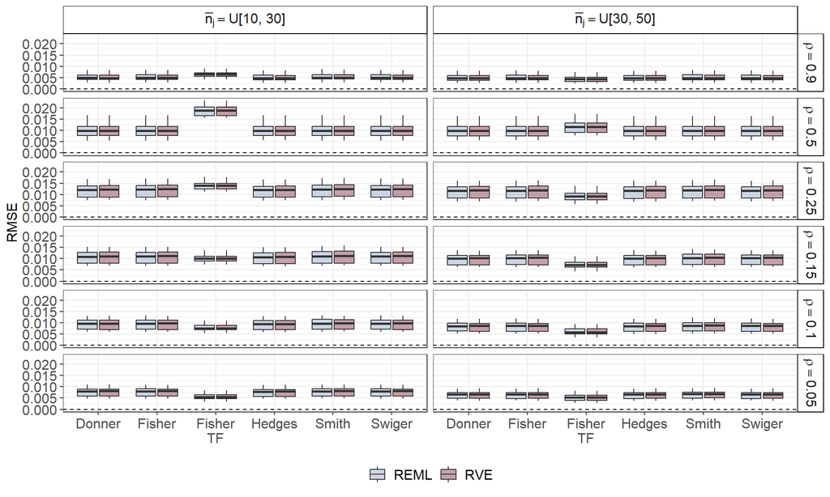

## Results - Relative Standard Error Bias ($\overline{n}_j$)

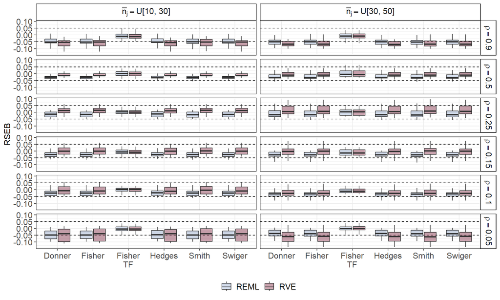

## RPB $k$

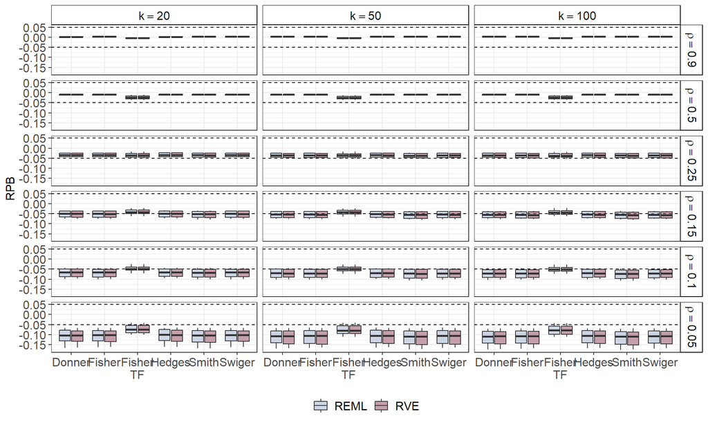

## PB $k$

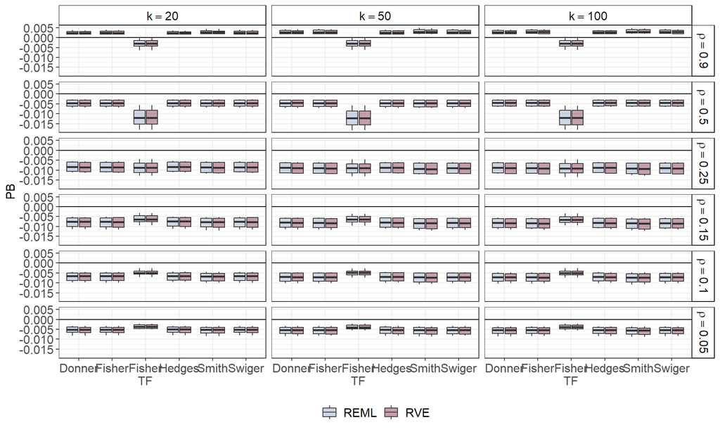

## L2 Variance by $\tau_{\rho}$

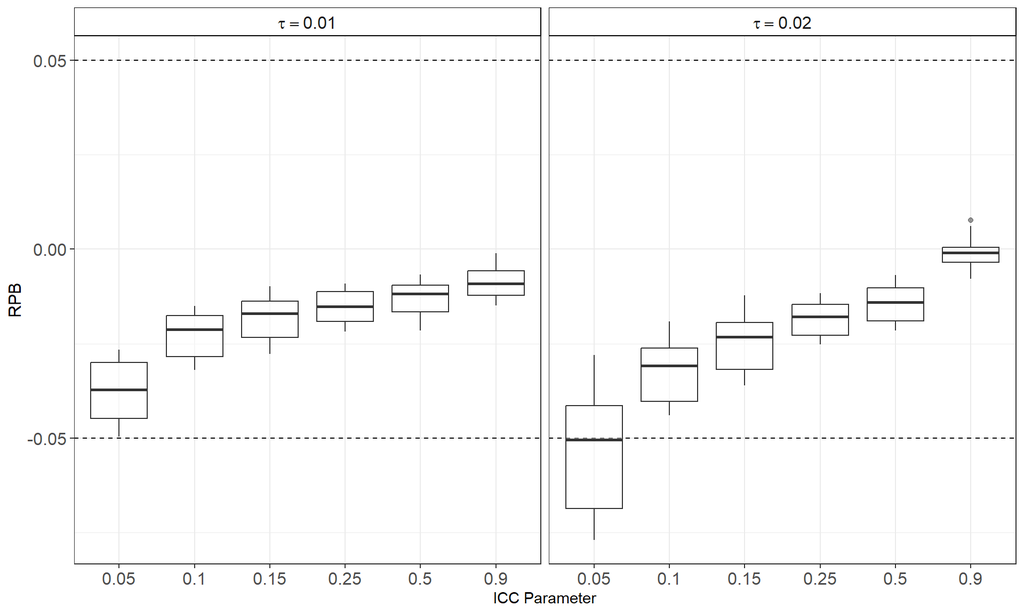

## L2 Variance by Number of Clusters

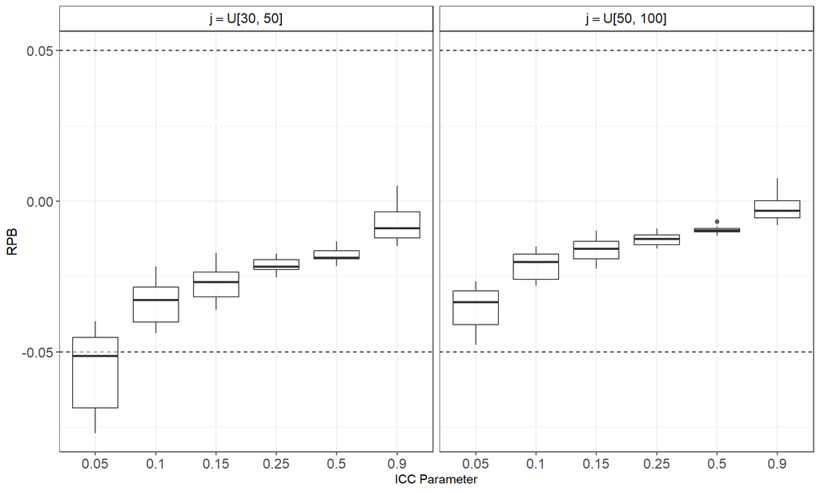

## L1 Variance by Clustersize

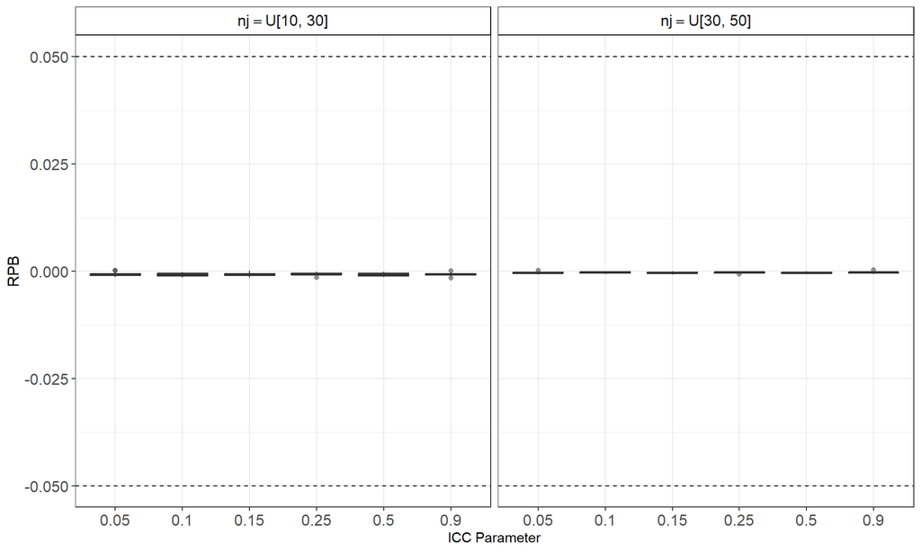